# Beer Case Study

Will Holt and Yejur Kunwar

October 17, 2017

### Background:

Reyes Beverage Group (Reyes), one of the largest beer distributor in the United States, is looking to brew its own beer in an effort to expand its own business. Specifically, Reyes is looking to produce seasonal beers with an alcohol by volume (ABV) content between 0.05 and 0.07. Reyes contacted Last Call Consulting (LCC) to determine states that are potential markets.

### Scope:

LCC cleaned, and analyzed a list of beers and breweries by state from Open Beer DB (https://openbeerdb.com/). The analysis identified the top three states Reyes should target for its seasonal beers.

### Key Findings:

LCC determined that more than 75% of the beers were greater than or equal to 0.05 and that 25% of beers were greater than or equal to 0.067. This suggests that Reyes is producing a beer with an ABV that is not unsual for the market. LCC identified Connecticut (CT), Maryland (MD), and Illinois (IL) as the three markets to target for their initial line of seasonal beers. CT, MD, and IL currently have eight, seven and 18 breweries respectively and a median ABV of 0.06 for CT, 0.058 for MD, and 0.058 for IL. CT’s relative proiximity to New York City (NYC) may be advantageous as word of the new beer may spread amongst individuals who commute from CT to NYC. MD’s close proximity to Washington D.C. (DC) could help Reyes gain entry to the DC market, which only has one brewery. IL allows Reyes to save money on shipping costs as it is located in Chicago and can leverage its relationships with Chicago business to help launch its product. As the product grows, Minnesota (MN) could be another midwestern market for Reyes to targt as it has 12 breweries and a median ABV of 0.056.

### Deliverables:

LCC provided an RMarkdown file, which included the associated codes so that Reyes can reproduce the research conducted and follow-up with any questions as needed. In addition, LCC produced a codebook and ReadMe file to ensure alignment and proper understanding of the variables and findings. Within the RMarkedown file are key questions posed by Reyes CIO, Faizan Javed.

```r
Beer <- read.csv("Beers.csv")
Breweries <- read.csv("Breweries.csv")
```

```r
names(Beer) <- c("BeerName", "BeerID", "ABV", "IBU", "BreweryID", "BeerStyle", "Ounces")
str(Beer)
```

```
## 'data.frame':    2410 obs. of  7 variables:
##  $ BeerName : Factor w/ 2305 levels "#001 Golden Amber Lager",..: 1638 577 1704 1842 1819 268 1160 758 1093 486 ...
##  $ BeerID   : int  1436 2265 2264 2263 2262 2261 2260 2259 2258 2131 ...
##  $ ABV      : num  0.05 0.066 0.071 0.09 0.075 0.077 0.045 0.065 0.055 0.086 ...
##  $ IBU      : int  NA NA NA NA NA NA NA NA NA NA ...
##  $ BreweryID: int  409 178 178 178 178 178 178 178 178 178 ...
##  $ BeerStyle: Factor w/ 100 levels "","Abbey Single Ale",..: 19 18 16 12 16 80 18 22 18 12 ...
##  $ Ounces   : num  12 12 12 12 12 12 12 12 12 12 ...
```

```r
names(Breweries) <- c("BreweryID", "BreweryName", "BreweryCity", "BreweryState")
str(Breweries)
```

```
## 'data.frame':    558 obs. of  4 variables:
##  $ BreweryID   : int  1 2 3 4 5 6 7 8 9 10 ...
##  $ BreweryName : Factor w/ 551 levels "10 Barrel Brewing Company",..: 355 12 266 319 201 136 227 477 59 491 ...
##  $ BreweryCity : Factor w/ 384 levels "Abingdon","Abita Springs",..: 228 200 122 299 300 62 91 48 152 136 ...
##  $ BreweryState: Factor w/ 51 levels " AK"," AL"," AR",..: 24 18 20 5 5 41 6 23 23 23 ...
```

### 1. How many breweries are present in each state?

There were instances in which a brewery appeared more than once in a state but was counted twice to show how breweries are successful in multiple cities throughout a state and to truly represent the number of breweries per state. Should the CIO, Faizan Javed need to understand the unique count based on name only, LCC will provide updated findings.

```r
#A unique brewery is defined as a Brewery appearing in a different city (e.g. Victory Brewing, Kennett; Victory Brewing, Downingtown)
StateBreweries <- as.data.frame(table(Breweries$BreweryState))
names(StateBreweries) <- c("BreweryState", "BreweryCount")
StateBreweries
```

```
##    BreweryState BreweryCount
## 1            AK            7
## 2            AL            3
## 3            AR            2
## 4            AZ           11
## 5            CA           39
## 6            CO           47
## 7            CT            8
## 8            DC            1
## 9            DE            2
## 10           FL           15
## 11           GA            7
## 12           HI            4
## 13           IA            5
## 14           ID            5
```

[output cut: 37 more lines]

### 2. Merge beer data with the breweries data. Print the first 6 observations and the last six observations to check the merged file.

```r
BeerStudy <- merge(Beer,Breweries,by="BreweryID")
head(BeerStudy, 6)
```

```
##   BreweryID      BeerName BeerID   ABV IBU
## 1         1  Get Together   2692 0.045  50
## 2         1 Maggie's Leap   2691 0.049  26
## 3         1    Wall's End   2690 0.048  19
## 4         1       Pumpion   2689 0.060  38
## 5         1    Stronghold   2688 0.060  25
## 6         1   Parapet ESB   2687 0.056  47
##                             BeerStyle Ounces        BreweryName
## 1                        American IPA     16 NorthGate Brewing
## 2                  Milk / Sweet Stout     16 NorthGate Brewing
## 3                   English Brown Ale     16 NorthGate Brewing
## 4                         Pumpkin Ale     16 NorthGate Brewing
## 5                     American Porter     16 NorthGate Brewing
## 6 Extra Special / Strong Bitter (ESB)     16 NorthGate Brewing
##   BreweryCity BreweryState
## 1 Minneapolis           MN
## 2 Minneapolis           MN
## 3 Minneapolis           MN
## 4 Minneapolis           MN
## 5 Minneapolis           MN
## 6 Minneapolis           MN
```

```r
tail(BeerStudy, 6)
```

```
##      BreweryID                  BeerName BeerID   ABV IBU
## 2405       556             Pilsner Ukiah     98 0.055  NA
## 2406       557  Heinnieweisse Weissebier     52 0.049  NA
## 2407       557           Snapperhead IPA     51 0.068  NA
## 2408       557         Moo Thunder Stout     50 0.049  NA
## 2409       557         Porkslap Pale Ale     49 0.043  NA
## 2410       558 Urban Wilderness Pale Ale     30 0.049  NA
##                    BeerStyle Ounces                   BreweryName
## 2405         German Pilsener     12         Ukiah Brewing Company
## 2406              Hefeweizen     12       Butternuts Beer and Ale
## 2407            American IPA     12       Butternuts Beer and Ale
## 2408      Milk / Sweet Stout     12       Butternuts Beer and Ale
## 2409 American Pale Ale (APA)     12       Butternuts Beer and Ale
## 2410        English Pale Ale     12 Sleeping Lady Brewing Company
##        BreweryCity BreweryState
## 2405         Ukiah           CA
## 2406 Garrattsville           NY
## 2407 Garrattsville           NY
## 2408 Garrattsville           NY
## 2409 Garrattsville           NY
## 2410     Anchorage           AK
```

### 3. Report the number of NA’s in each column.

```r
colSums(is.na(BeerStudy))
```

```
##    BreweryID     BeerName       BeerID          ABV          IBU
##            0            0            0           62         1005
##    BeerStyle       Ounces  BreweryName  BreweryCity BreweryState
##            0            0            0            0            0
```

### 4. Compute the median alcohol content and international bitterness unit for each state. Plot a bar chart to compare.

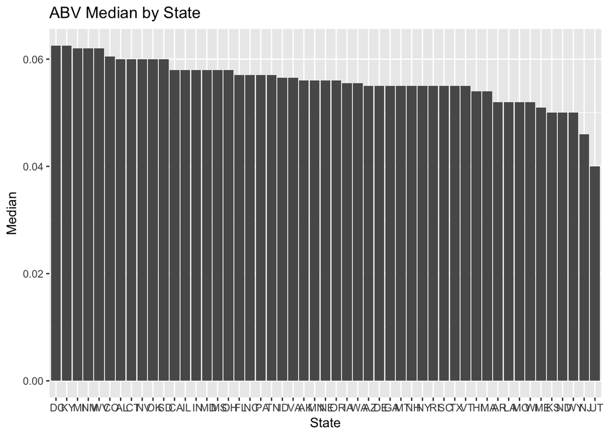

```r
library(ggplot2)
#First set of code represents ABV Median by State
ABVMedian <- aggregate(BeerStudy$ABV ~ BeerStudy$BreweryState, data = BeerStudy, median)
names(ABVMedian) <- c("State", "ABV")
ABVMedian <- ABVMedian[order(ABVMedian$ABV,decreasing = TRUE),]
ggplot(data = ABVMedian, aes(x=reorder(ABVMedian$State, -ABVMedian$ABV), y=ABVMedian$ABV)) +
geom_bar(stat = "identity") +
labs(title = "ABV Median by State", x = "State", y = "Median")
```

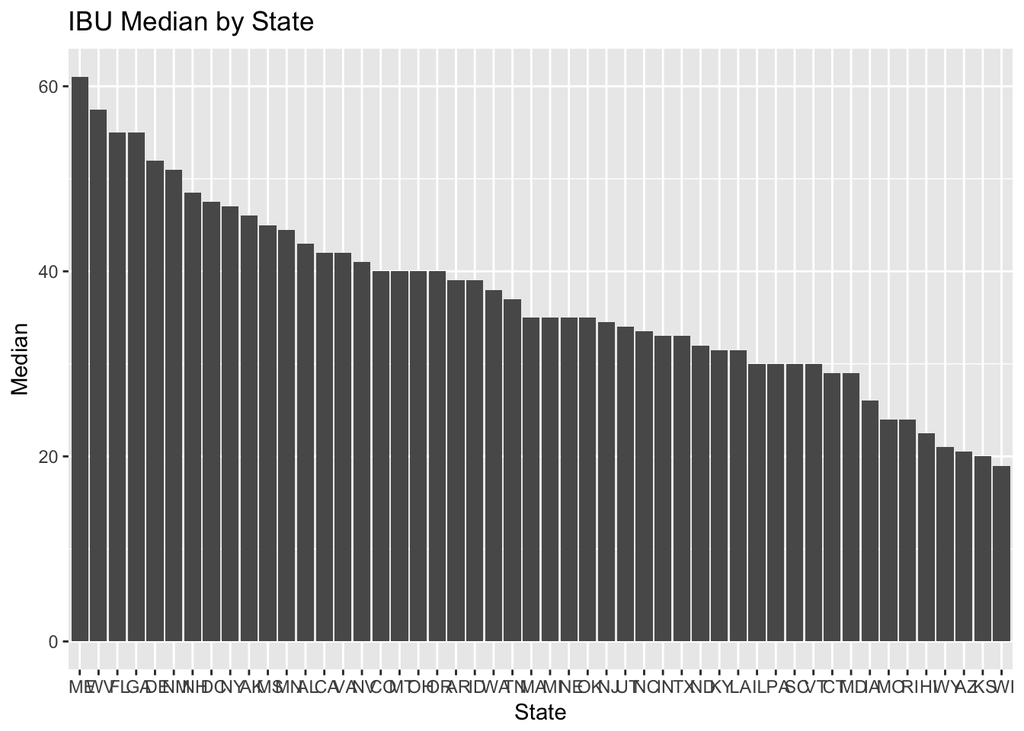

```r
#Second set of code represents IBU Median by State
IBUMedian <- aggregate(BeerStudy$IBU ~ BeerStudy$BreweryState, data = BeerStudy, median)
names(IBUMedian) <- c("State", "IBU")
IBUMedian <- IBUMedian[order(IBUMedian$IBU,decreasing = TRUE),]
ggplot(data = IBUMedian, aes(x=reorder(IBUMedian$State, -IBUMedian$IBU), y=IBUMedian$IBU)) +
geom_bar(stat = "identity") +
labs(title = "IBU Median by State", x = "State", y = "Median")
```

### 5. Which state has the maximum alcoholic (ABV) beer? Which state has the most bitter (IBU) beer?

```r
#First code identifies the state with the highest ABV
head(ABVMedian, 1)
```

```
##   State    ABV
## 8    DC 0.0625
```

```r
#Second code identifies the state with the highest IBU
head(IBUMedian, 1)
```

```
##    State IBU
## 22    ME  61
```

### 6. Summary statistics for the ABV variable.

```r
summary(BeerStudy$ABV)
```

```
##    Min. 1st Qu.  Median    Mean 3rd Qu.    Max.    NA's
## 0.00100 0.05000 0.05600 0.05977 0.06700 0.12800      62
```

### 7. Is there an apparent relationship between the bitterness of the beer and its alcoholic content? Draw a scatter plot.

Based on the visuals produced from the following code and an r-value of 0.6706215 we can see there is a moderate correlation between ABV and IBU in this particular dataset.

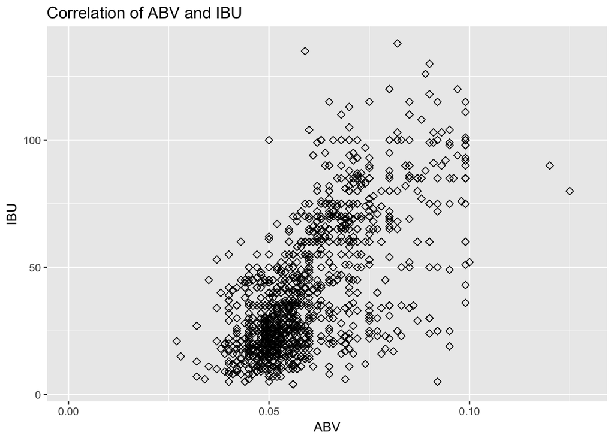

```r
ggplot(BeerStudy, aes(x=BeerStudy$ABV, y=BeerStudy$IBU)) +
geom_point(size=2, shape=23) +
labs(title = "Correlation of ABV and IBU", x = "ABV", y = "IBU")
```

```r
#The following code will calcuate the r value and represents the coorelation between ABV and IBU
cor.test(BeerStudy$ABV, BeerStudy$IBU)
```

```
##
##  Pearson's product-moment correlation
##
## data:  BeerStudy$ABV and BeerStudy$IBU
## t = 33.863, df = 1403, p-value < 2.2e-16
## alternative hypothesis: true correlation is not equal to 0
## 95 percent confidence interval:
##  0.6407982 0.6984238
## sample estimates:
##       cor
## 0.6706215
```

- Link for github: https://github.com/WillHolt-SMU/Beer-Case-Study